# ANOVA for temporal vegatation data

Lia Ossanna

2023-05-26

# Introduction

- This is the code and results of plotting temporal veg data over time, with response variables of total cover, herbaceous cover, notree cover (shrubs, grasses, forbs), perennial richness (includes trees), and perennial diversity (includes trees).
- We are using `Treatment3` which is a grouping of `Control` (Channels 12 & 19) and `Treated` (Channels 13 & 21), because this is the best way to look at the local effects of rock structures.
- Repeat measures ANOVA is used to compare overall means between Control & Treated.
  - Because all the channels are different, these results are less relevant because what matters is how the channels change over time, not their overall inherent conditions.
  - We look at repeat measures ANOVA in three ways:
    1. Using `aov()`.
    2. Using `lme4` package, with `Year` as a random factor. Then use `performance` package to check the model, and `car` package to run the ANOVA on the linear model.
    3. Using `nlme` package, with `Year` as a random factor. Then use `emmeans` package to compare the means.

# Previous iterations of analysis

- The iterations here concern the temporal veg data collected from 2012 to 2021, not the additional soil data collected in the last year only (2021).
- Presentations:
  - AVCA data sharing event, Jan 2022
  - National SRM, Feb 2022
  - AZ SRM, Feb 2023
  - National SRM, Feb 2023
  - ALVSCE research poster forum, Mar 2023
- Response variables for cover included total cover and herbaceous cover (presentations up through ALVSCE in March 2023). Have not presented results of notree data anywhere yet.
- Treatments:
  - Treatments are numbered more or less according to how I went through stages of analysis. `Treatment1` groups by the local station as `No treatment` (Channels 12 & 19), `Baffle`, and `One rock dam`. I never really used this for anything, because I decided that I didn’t want to look at differences between baffles & ORD (study wasn’t really set up that way and getting into those details is too much).
  - Initially had used `Channel` for grouping (looked at each channel individually), which was better for presentation to AVCA, who are very familiar with the study area and project. Presented results grouped by `Channel` to AVCA data sharing meeting, and SRM 2022. Concluded that herbaceous cover increased over time for Channels 13 & 21, but also went with this conflicting sort of message that in-channel treatments promoted resiliency because total cover did not change over time.
  - Then switched to grouping by `Treatment2`, which was `No treatment` (Channel 12), `Upland treatment` (Channel 19), and `In-channel treatment` (Channels 13 & 21). I was worried that Channels 12 & 19 couldn’t be considered to be of the same treatment, since technically they weren’t. But this made weird grouping (unbalanced sample sizes, which I accounted for, but still), and I couldn’t determine the effect of the upland structures because we didn’t have like “distance to nearest structure” measured, or something like that. I presented with this grouping at AZ SRM 2023 and national SRM 2023. Saw strong differences between treatments because Channel 19 is very different than Channel 12, but ultimately couldn’t defend why I was grouping things like this, and it made the narrative more complicated.
  - Now have settled on `Treatment3` grouping, which is simply `Control` and `Treated`. Presented these results at the ALVSCE poster forum in March 2023, and will stick with this grouping from now on. Sample sizes are more balanced, and this is best for looking at the local effect of the rocks.

# Summary

- Will use notree cover for publication because conceptually, this is the best measurement of what we want to capture. The influence of tree cover (only trees are palo verde and mesquite) is not really what we’re getting at, because we want to look at the local effect of the rock structures, and we don’t think tree cover will chnage much over time, but it could obscure changes from other plants. Not using herbaceous cover, because based on monitoring photos, there are shrubs that are growing near rock structures that likely contribute to erosion control and sediment deposition.

## Relevant figures

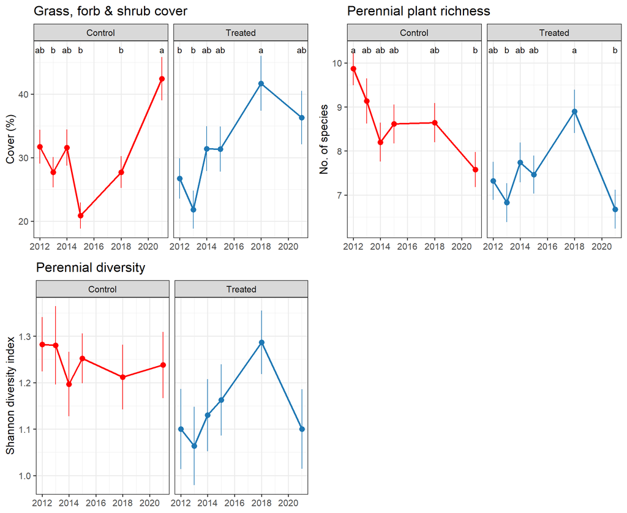

# Setup

```r
library(tidyverse)
library(agricolae)
library(plotrix)
library(car)
library(lme4)
library(nlme)
library(performance)
library(emmeans)
library(ggpubr)

# Load data ---------------------------------------------------------------

total.all <- read_csv("data/cleaned/Summarised-all_total-plant-cover.csv")
herb.all <- read_csv("data/cleaned/Summarised-all_herb-cover.csv")
notree.all <- read_csv("data/cleaned/Summarised-all_notree-cover.csv")
per.div <- read_csv("data/cleaned/Summarised-all_perennial-diversity.csv")


# Functions ---------------------------------------------------------------

# Convert columns to factor or date as needed
convert.cols <- function(x) {
  x$year.xaxis <- as.Date(x$year.xaxis)

  group.cols <- c("Sample", "Year", "Channel", "Station", "Treatment1", "Treatment2", "Treatment3")

  x[group.cols] <- lapply(x[group.cols], factor)

  return(x)
}


# Data wrangling ----------------------------------------------------------

total.all <- convert.cols(total.all)
herb.all <- convert.cols(herb.all)
notree.all <- convert.cols(notree.all)
per.div <- convert.cols(per.div)
```

# Total plant cover

## Find averages by year

```r
# Find averages by year
total.avg <- total.all %>%
  group_by(Treatment3, Year, year.xaxis) %>%
  summarise(mean = mean(Cover),
            SD = sd(Cover),
            SE = std.error(Cover),
            .groups = "keep")

write.csv(total.avg,
          file = "data/cleaned/Treatment3-average_total-cover.csv",
          row.names = FALSE)
```

## Plot

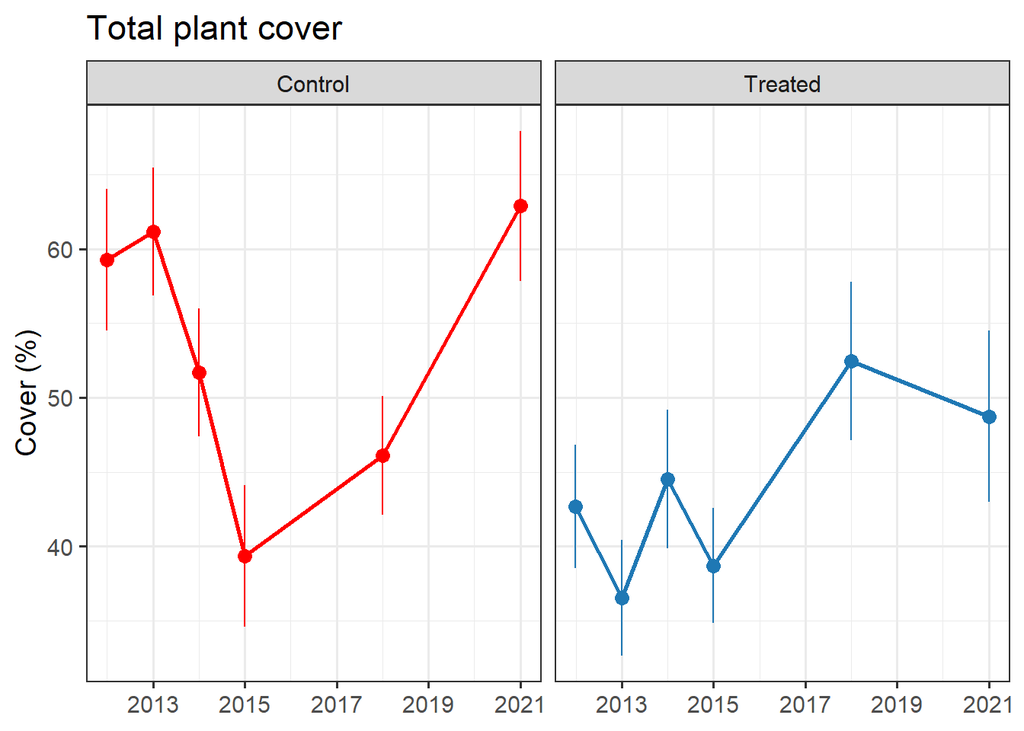

```r
ggplot(total.avg, aes(x = year.xaxis, y = mean,
                      group = Treatment3,
                      color = Treatment3)) +
  geom_line(linewidth = 1) +
  geom_point(size = 3) +
  geom_pointrange(aes(ymin = mean - SE, ymax = mean + SE)) +
  scale_x_date(date_breaks = "2 years", date_labels = "%Y") +
  facet_wrap(~Treatment3) +
  xlab(NULL) +
  ylab("Cover (%)") +
  ggtitle("Total plant cover") +
  scale_color_manual(values = c("red", "#1F78B4")) +
  theme_bw(base_size = 14) +
  theme(legend.position = "none")
```

## Compare overall Control & Treated

### Repeat measures ANOVA

```r
anova.total <- aov(Cover ~ Treatment3 + Error(Year), data = total.all)
summary(anova.total)
```

```
##
## Error: Year
##            Df Sum Sq Mean Sq F value Pr(>F)
## Treatment3  1   1764    1764   0.953  0.384
## Residuals   4   7408    1852
##
## Error: Within
##             Df Sum Sq Mean Sq F value   Pr(>F)
## Treatment3   1   8013    8013   11.98 0.000601 ***
## Residuals  359 240025     669
## ---
## Signif. codes:  0 '***' 0.001 '**' 0.01 '*' 0.05 '.' 0.1 ' ' 1
```

```r
summary(aov(Cover ~ Treatment3, data = total.all)) # without repeat measures to compare
```

```
##              Df Sum Sq Mean Sq F value   Pr(>F)
## Treatment3    1   7910    7910   11.55 0.000753 ***
## Residuals   364 249299     685
## ---
## Signif. codes:  0 '***' 0.001 '**' 0.01 '*' 0.05 '.' 0.1 ' ' 1
```

- Significant difference between channels.

### Year as random factor

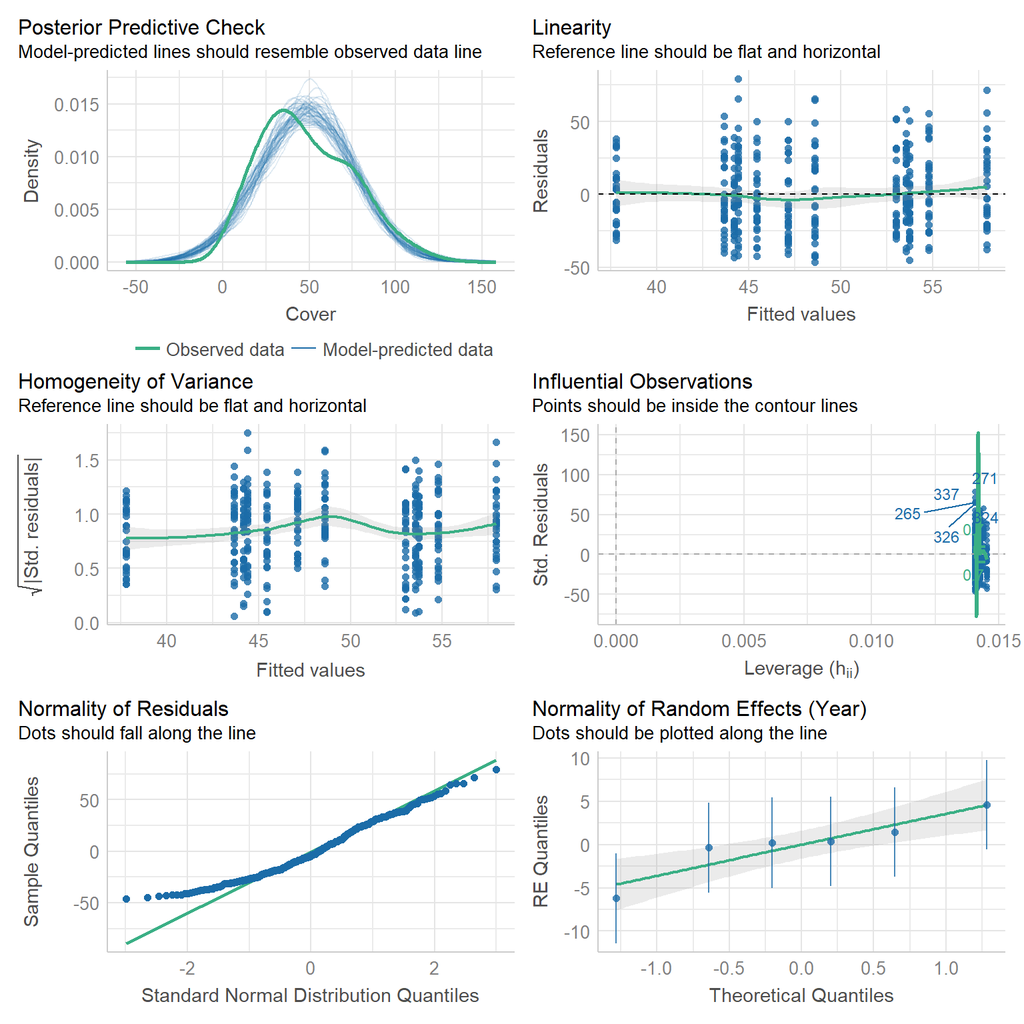

```r
# Using lme4 & car
lm.total <- lmer(Cover ~ Treatment3 + (1|Year), data = total.all)
check_model(lm.total)
```

```r
Anova(lm.total)
```

```
## Analysis of Deviance Table (Type II Wald chisquare tests)
##
## Response: Cover
##             Chisq Df Pr(>Chisq)
## Treatment3 11.929  1  0.0005526 ***
## ---
## Signif. codes:  0 '***' 0.001 '**' 0.01 '*' 0.05 '.' 0.1 ' ' 1
```

```r
# Using nlme & emmeans
lm2.total <- lme(Cover ~ Treatment3, random = ~1|Year, data = total.all)
emmeans(lm2.total, specs = "Treatment3") # Control > Treated
```

```
##  Treatment3 emmean   SE df lower.CL upper.CL
##  Control      53.3 2.62  5     46.6     60.1
##  Treated      44.0 2.62  5     37.3     50.8
##
## Degrees-of-freedom method: containment
## Confidence level used: 0.95
```

- Significant difference between channels.

## Temporal one-way ANOVA

```r
# One-way ANOVA for Treated
summary(aov(Cover ~ Year, data = filter(total.all, Treatment3 == "Treated"))) # NS
```

```
##              Df Sum Sq Mean Sq F value Pr(>F)
## Year          5   5447  1089.3   1.626  0.155
## Residuals   177 118602   670.1
```

```r
# One-way ANOVA for Control
summary(aov(Cover ~ Year, data = filter(total.all, Treatment3 == "Control")))
```

```
##              Df Sum Sq Mean Sq F value  Pr(>F)
## Year          5  13484  2696.7   4.271 0.00108 **
## Residuals   177 111767   631.5
## ---
## Signif. codes:  0 '***' 0.001 '**' 0.01 '*' 0.05 '.' 0.1 ' ' 1
```

```r
total.ctrl <- total.all |>
  filter(Treatment3 == "Control")
anova.total.ctrl <- aov(total.ctrl$Cover ~ total.ctrl$Year)
hsd.total.ctrl <- HSD.test(anova.total.ctrl, trt = "total.ctrl$Year")
hsd.total.ctrl
```

```
## $statistics
##    MSerror  Df     Mean       CV
##   631.4532 177 53.34005 47.11044
##
## $parameters
##    test          name.t ntr StudentizedRange alpha
##   Tukey total.ctrl$Year   6         4.074627  0.05
##
## $means
##      total.ctrl$Cover      std  r      Min      Max      Q25      Q50      Q75
## 2012         59.25694 26.14399 30 16.66667 110.2500 39.27083 59.33333 73.97917
## 2013         61.16528 23.59477 30 14.33333 111.8333 44.77083 61.12500 80.04167
## 2014         51.68333 23.67531 30 22.50000 104.8750 32.03125 52.18750 61.59375
## 2015         39.35282 26.44873 31  6.25000  97.0000 17.06250 31.25000 56.25000
## 2018         46.09274 22.27264 31  8.68750 104.3750 27.87500 41.25000 59.56250
## 2021         62.87903 28.09362 31 20.25000 129.5000 37.25000 55.50000 82.06250
##
## $comparison
## NULL
##
## $groups
##      total.ctrl$Cover groups
## 2021         62.87903      a
## 2013         61.16528      a
## 2012         59.25694      a
## 2014         51.68333     ab
## 2018         46.09274     ab
## 2015         39.35282      b
##
## attr(,"class")
## [1] "group"
```

## Plot with one-way ANOVA letters

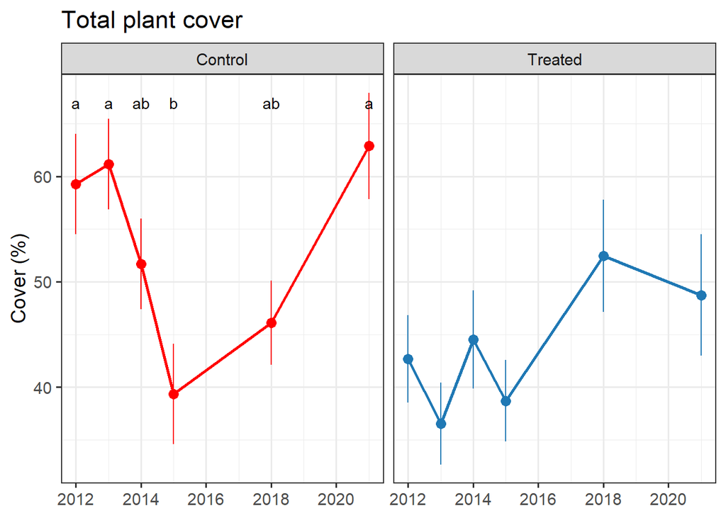

```r
total.ctrl.letters <- hsd.total.ctrl$groups
total.ctrl.letters <- total.ctrl.letters |>
  mutate(Year = rownames(total.ctrl.letters)) |>
  arrange(Year)

letters.total <- data.frame(x = total.avg$year.xaxis[1:6],
                      y = rep(67, 6),
                      label = total.ctrl.letters$groups,
                      Treatment3 = c(rep("Control", 6)))
total.plot <- ggplot(total.avg, aes(x = year.xaxis, y = mean,
                     group = Treatment3,
                     color = Treatment3)) +
  geom_line(linewidth = 1) +
  geom_point(size = 3) +
  geom_pointrange(aes(ymin = mean - SE, ymax = mean + SE)) +
  facet_wrap(~Treatment3) +
  xlab(NULL) +
  ylab("Cover (%)") +
  ggtitle("Total plant cover") +
  scale_color_manual(values = c("red", "#1F78B4")) +
  theme_bw(base_size = 14) +
  theme(legend.position = "none") +
  geom_text(data = letters.total,
            mapping = aes(x = x, y = y, label = label),
            color = "black")
total.plot
```

# Herbaceous plant cover

## Find averages by year

```r
# Find averages by year
herb.avg <- herb.all %>%
  group_by(Treatment3, Year, year.xaxis) %>%
  summarise(mean = mean(Cover),
            SD = sd(Cover),
            SE = std.error(Cover),
            .groups = "keep")

write.csv(herb.avg,
          file = "data/cleaned/Treatment3-average_herb-cover.csv",
          row.names = FALSE)
```

## Plot

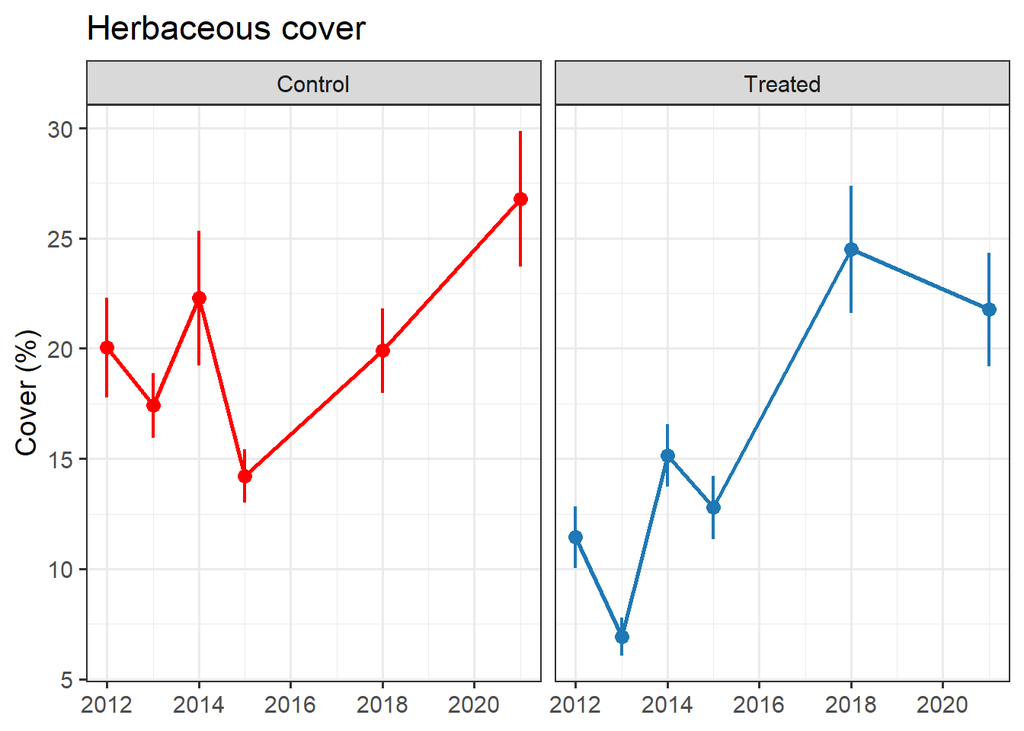

```r
ggplot(herb.avg, aes(x = year.xaxis, y = mean,
                     group = Treatment3,
                     color = Treatment3)) +
  geom_line(linewidth = 1) +
  geom_point(size = 3) +
  geom_pointrange(aes(ymin = mean - SE, ymax = mean + SE),  linewidth = 0.8) +
  facet_wrap(~Treatment3) +
  xlab(NULL) +
  ylab("Cover (%)") +
  ggtitle("Herbaceous cover") +
  scale_color_manual(values = c("red", "#1F78B4")) +
  theme_bw(base_size = 14) +
  theme(legend.position = "none")
```

## Compare overall Control & Treated

### Repeat measures ANOVA

```r
anova.herb <- aov(Cover ~ Treatment3 + Error(Year), data = herb.all)
summary(anova.herb)
```

```
##
## Error: Year
##            Df Sum Sq Mean Sq F value Pr(>F)
## Treatment3  1   1105    1105   0.743  0.437
## Residuals   4   5946    1486
##
## Error: Within
##             Df Sum Sq Mean Sq F value   Pr(>F)
## Treatment3   1   1957  1957.1   13.93 0.000221 ***
## Residuals  359  50444   140.5
## ---
## Signif. codes:  0 '***' 0.001 '**' 0.01 '*' 0.05 '.' 0.1 ' ' 1
```

```r
summary(aov(Cover ~ Treatment3, data = herb.all)) # without repeat measures to compare
```

```
##              Df Sum Sq Mean Sq F value   Pr(>F)
## Treatment3    1   1917  1917.4   12.13 0.000556 ***
## Residuals   364  57535   158.1
## ---
## Signif. codes:  0 '***' 0.001 '**' 0.01 '*' 0.05 '.' 0.1 ' ' 1
```

- Significant difference between channels.

### Year as random factor

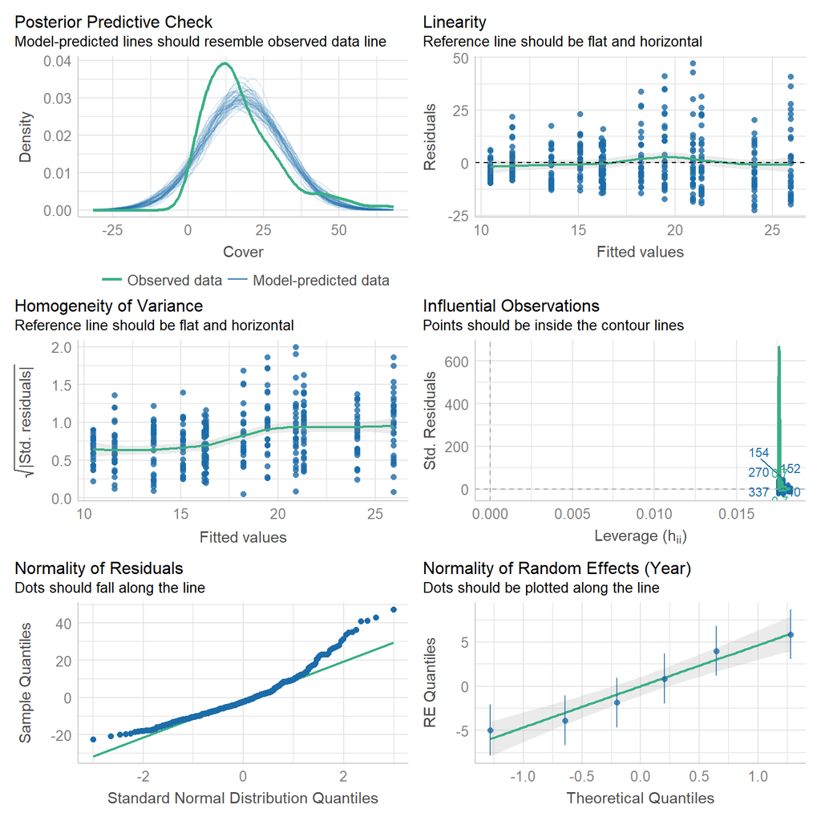

```r
# Using lme4 & car
lm.herb <- lmer(Cover ~ Treatment3 + (1|Year), data = herb.all)
check_model(lm.herb)
```

```r
Anova(lm.herb)
```

```
## Analysis of Deviance Table (Type II Wald chisquare tests)
##
## Response: Cover
##             Chisq Df Pr(>Chisq)
## Treatment3 13.899  1  0.0001929 ***
## ---
## Signif. codes:  0 '***' 0.001 '**' 0.01 '*' 0.05 '.' 0.1 ' ' 1
```

```r
# Using nlme & emmeans
lm2.herb <- lme(Cover ~ Treatment3, random = ~1|Year, data = herb.all)
emmeans(lm2.herb, specs = "Treatment3") # Control > Treated
```

```
##  Treatment3 emmean   SE df lower.CL upper.CL
##  Control      20.1 2.06  5     14.8     25.4
##  Treated      15.5 2.06  5     10.1     20.8
##
## Degrees-of-freedom method: containment
## Confidence level used: 0.95
```

- Significant difference between channels.

## Temporal one-way ANOVA

```r
# One-way ANOVA for Treated
summary(aov(Cover ~ Year, data = filter(herb.all, Treatment3 == "Treated")))
```

```
##              Df Sum Sq Mean Sq F value   Pr(>F)
## Year          5   6588  1317.6   11.64 9.86e-10 ***
## Residuals   177  20042   113.2
## ---
## Signif. codes:  0 '***' 0.001 '**' 0.01 '*' 0.05 '.' 0.1 ' ' 1
```

```r
herb.trt <- herb.all |>
  filter(Treatment3 == "Treated")
anova.herb.trt <- aov(herb.trt$Cover ~ herb.trt$Year) # p = 9.86e-10 ***
hsd.herb.trt <- HSD.test(anova.herb.trt, trt = "herb.trt$Year")
hsd.herb.trt
```

```
## $statistics
##    MSerror  Df     Mean       CV
##   113.2311 177 15.53026 68.51792
##
## $parameters
##    test        name.t ntr StudentizedRange alpha
##   Tukey herb.trt$Year   6         4.074627  0.05
##
## $means
##      herb.trt$Cover       std  r       Min      Max     Q25      Q50       Q75
## 2012      11.436828  7.794176 31 0.7500000 31.25000  4.7500 12.58333 16.166667
## 2013       6.929598  4.651510 29 0.8333333 16.66667  3.2500  6.25000  9.916667
## 2014      15.139113  7.864820 31 2.2500000 32.25000  9.3750 15.00000 21.062500
## 2015      12.781250  7.892338 30 3.2500000 33.50000  7.5625 10.12500 15.406250
## 2018      24.489919 16.049193 31 2.3750000 60.75000 12.3125 20.25000 33.937500
## 2021      21.761290 14.404014 31 2.1250000 52.87500  8.8000 19.00000 30.375000
##
## $comparison
## NULL
##
## $groups
##      herb.trt$Cover groups
## 2018      24.489919      a
## 2021      21.761290     ab
## 2014      15.139113     bc
## 2015      12.781250     cd
## 2012      11.436828     cd
## 2013       6.929598      d
##
## attr(,"class")
## [1] "group"
```

```r
# One-way ANOVA for Control
summary(aov(Cover ~ Year, data = filter(herb.all, Treatment3 == "Control")))
```

```
##              Df Sum Sq Mean Sq F value  Pr(>F)
## Year          5   2821   564.3   3.556 0.00434 **
## Residuals   177  28083   158.7
## ---
## Signif. codes:  0 '***' 0.001 '**' 0.01 '*' 0.05 '.' 0.1 ' ' 1
```

```r
herb.ctrl <- herb.all |>
  filter(Treatment3 == "Control")
anova.herb.ctrl <- aov(herb.ctrl$Cover ~ herb.ctrl$Year)
hsd.herb.ctrl <- HSD.test(anova.herb.ctrl, trt = "herb.ctrl$Year")
hsd.herb.ctrl
```

```
## $statistics
##   MSerror  Df     Mean       CV
##   158.662 177 20.10792 62.64253
##
## $parameters
##    test         name.t ntr StudentizedRange alpha
##   Tukey herb.ctrl$Year   6         4.074627  0.05
##
## $means
##      herb.ctrl$Cover       std  r      Min     Max      Q25    Q50     Q75
## 2012        20.03472 12.343368 30 3.750000 52.0000 12.02083 15.625 26.8125
## 2013        17.41528  8.055665 30 1.916667 38.2500 12.83333 16.875 22.2500
## 2014        22.28333 16.755369 30 2.500000 68.1250 10.90625 18.375 29.2500
## 2015        14.21169  6.759805 31 1.875000 27.8750 10.25000 12.625 18.0625
## 2018        19.89718 10.721735 31 1.625000 44.5625 13.50000 19.250 27.0000
## 2021        26.78629 17.148188 31 6.250000 67.0000 13.12500 22.250 37.7500
##
## $comparison
## NULL
##
## $groups
##      herb.ctrl$Cover groups
## 2021        26.78629      a
## 2014        22.28333     ab
## 2012        20.03472     ab
## 2018        19.89718     ab
## 2013        17.41528      b
## 2015        14.21169      b
##
## attr(,"class")
## [1] "group"
```

## Plot with one-way ANOVA letters

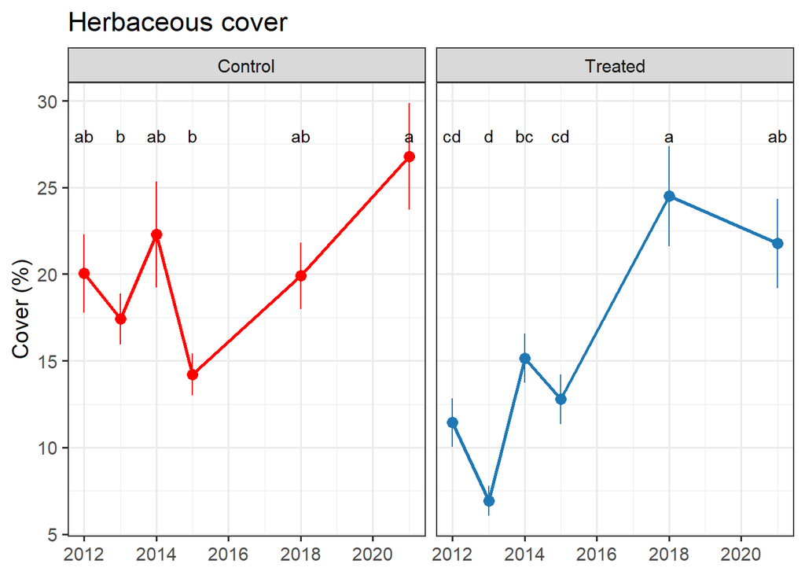

```r
herb.ctrl.letters <- hsd.herb.ctrl$groups
herb.ctrl.letters <- herb.ctrl.letters |>
  mutate(Year = rownames(herb.ctrl.letters)) |>
  arrange(Year)
herb.trt.letters <- hsd.herb.trt$groups
herb.trt.letters <-herb.trt.letters |>
  mutate(Year = rownames(herb.trt.letters)) |>
  arrange(Year)

letters.herb <- data.frame(x = rep(herb.avg$year.xaxis[1:6], 2),
                      y = rep(28, 12),
                      label = c(herb.ctrl.letters$groups,
                                herb.trt.letters$groups),
                      Treatment3 = c(rep("Control", 6),
                                     rep("Treated", 6)))
herb.plot <- ggplot(herb.avg, aes(x = year.xaxis, y = mean,
                     group = Treatment3,
                     color = Treatment3)) +
  geom_line(linewidth = 1) +
  geom_point(size = 3) +
  geom_pointrange(aes(ymin = mean - SE, ymax = mean + SE)) +
  facet_wrap(~Treatment3) +
  xlab(NULL) +
  ylab("Cover (%)") +
  ggtitle("Herbaceous cover") +
  scale_color_manual(values = c("red", "#1F78B4")) +
  theme_bw(base_size = 14) +
  theme(legend.position = "none") +
  geom_text(data = letters.herb,
            mapping = aes(x = x, y = y, label = label),
            color = "black")
herb.plot
```

# Notree cover

## Find averages by year

```r
# Find averages by year
notree.avg <- notree.all %>%
  group_by(Treatment3, Year, year.xaxis) %>%
  summarise(mean = mean(Cover),
            SD = sd(Cover),
            SE = std.error(Cover),
            .groups = "keep")

write.csv(notree.avg,
          file = "data/cleaned/Treatment3-average_notree-cover.csv",
          row.names = FALSE)
```

## Plot

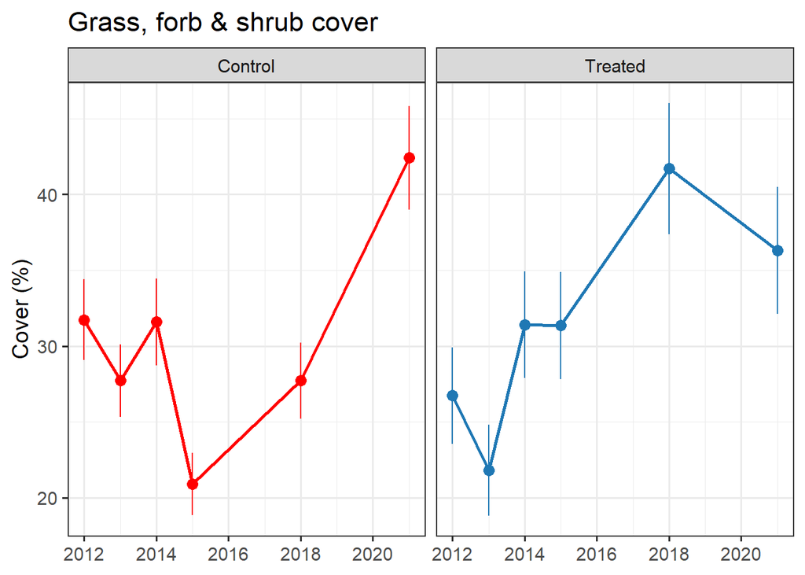

```r
ggplot(notree.avg, aes(x = year.xaxis, y = mean,
                       group = Treatment3,
                       color = Treatment3)) +
  geom_line(linewidth = 1) +
  geom_point(size = 3) +
  geom_pointrange(aes(ymin = mean - SE, ymax = mean + SE)) +
  facet_wrap(~Treatment3) +
  xlab(NULL) +
  ylab("Cover (%)") +
  ggtitle("Grass, forb & shrub cover") +
  scale_color_manual(values = c("red", "#1F78B4")) +
  theme_bw(base_size = 14) +
  theme(legend.position = "none")
```

## Compare overall Control & Treated

### Repeat measures ANOVA

```r
anova.notree <- aov(Cover ~ Treatment3 + Error(Year), data = notree.all)
summary(anova.notree) # NS
```

```
##
## Error: Year
##            Df Sum Sq Mean Sq F value Pr(>F)
## Treatment3  1   1465    1465   0.761  0.432
## Residuals   4   7702    1926
##
## Error: Within
##             Df Sum Sq Mean Sq F value Pr(>F)
## Treatment3   1    145   144.5    0.44  0.507
## Residuals  359 117807   328.2
```

```r
summary(aov(Cover ~ Treatment3, data = notree.all)) # without repeat measures to compare
```

```
##              Df Sum Sq Mean Sq F value Pr(>F)
## Treatment3    1    157   157.1    0.45  0.503
## Residuals   364 126961   348.8
```

- No significant difference between Control & Treated.

### Year as random factor

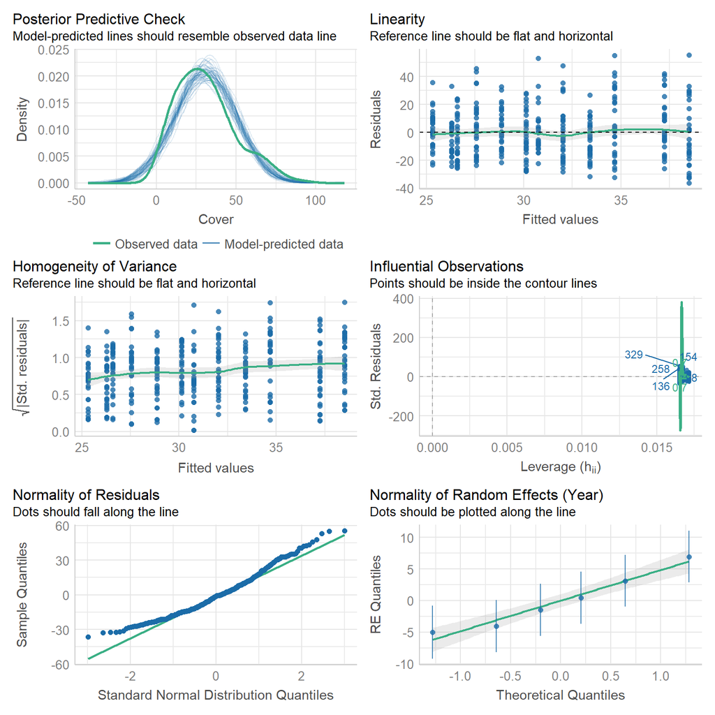

```r
# Using lme4 & car
lm.notree <- lmer(Cover ~ Treatment3 + (1|Year), data = notree.all)
check_model(lm.notree)
```

```r
Anova(lm.notree) # NS
```

```
## Analysis of Deviance Table (Type II Wald chisquare tests)
##
## Response: Cover
##             Chisq Df Pr(>Chisq)
## Treatment3 0.4473  1     0.5036
```

```r
# Using nlme & emmeans
lm2.notree <- lme(Cover ~ Treatment3, random = ~1|Year, data = notree.all)
emmeans(lm2.total, specs = "Treatment3")
```

```
##  Treatment3 emmean   SE df lower.CL upper.CL
##  Control      53.3 2.62  5     46.6     60.1
##  Treated      44.0 2.62  5     37.3     50.8
##
## Degrees-of-freedom method: containment
## Confidence level used: 0.95
```

- No significant difference between channels.

## Temporal one-way ANOVA

```r
# One-way ANOVA for Treated
summary(aov(Cover ~ Year, data = filter(notree.all, Treatment3 == "Treated"))) # p = 0.00416
```

```
##              Df Sum Sq Mean Sq F value  Pr(>F)
## Year          5   7371    1474   3.578 0.00416 **
## Residuals   177  72922     412
## ---
## Signif. codes:  0 '***' 0.001 '**' 0.01 '*' 0.05 '.' 0.1 ' ' 1
```

```r
notree.trt <- notree.all |>
  filter(Treatment3 == "Treated")
anova.notree.trt <- aov(notree.trt$Cover ~ notree.trt$Year)
hsd.notree.trt <- HSD.test(anova.notree.trt, trt = "notree.trt$Year")
hsd.notree.trt
```

```
## $statistics
##    MSerror  Df     Mean       CV
##   411.9877 177 31.65412 64.12271
##
## $parameters
##    test          name.t ntr StudentizedRange alpha
##   Tukey notree.trt$Year   6         4.074627  0.05
##
## $means
##      notree.trt$Cover      std  r       Min      Max      Q25      Q50      Q75
## 2012         26.72446 17.68227 31 2.0833333 58.16667 13.12500 23.08333 40.14583
## 2013         21.80029 16.10818 29 0.8333333 50.75000  6.75000 19.16667 35.50000
## 2014         31.40927 19.62855 31 3.6250000 79.75000 14.96875 27.50000 41.18750
## 2015         31.34792 19.42742 30 3.7500000 73.50000 15.31250 29.75000 42.84375
## 2018         41.69960 24.09989 31 2.3750000 89.75000 19.75000 37.62500 63.25000
## 2021         36.29758 23.34440 31 2.2500000 93.87500 20.68750 30.25000 52.25000
##
## $comparison
## NULL
##
## $groups
##      notree.trt$Cover groups
## 2018         41.69960      a
## 2021         36.29758     ab
## 2014         31.40927     ab
## 2015         31.34792     ab
## 2012         26.72446      b
## 2013         21.80029      b
##
## attr(,"class")
## [1] "group"
```

```r
# One-way ANOVA for Control
summary(aov(Cover ~ Year, data = filter(notree.all, Treatment3 == "Control")))
```

```
##              Df Sum Sq Mean Sq F value  Pr(>F)
## Year          5   7815  1563.0    7.12 4.3e-06 ***
## Residuals   177  38854   219.5
## ---
## Signif. codes:  0 '***' 0.001 '**' 0.01 '*' 0.05 '.' 0.1 ' ' 1
```

```r
notree.ctrl <- notree.all |>
  filter(Treatment3 == "Control")
anova.notree.ctrl <- aov(notree.ctrl$Cover ~ notree.ctrl$Year)
hsd.notree.ctrl <- HSD.test(anova.notree.ctrl, trt = "notree.ctrl$Year")
hsd.notree.ctrl
```

```
## $statistics
##    MSerror  Df     Mean       CV
##   219.5149 177 30.34369 48.82739
##
## $parameters
##    test           name.t ntr StudentizedRange alpha
##   Tukey notree.ctrl$Year   6         4.074627  0.05
##
## $means
##      notree.ctrl$Cover      std  r       Min      Max      Q25      Q50
## 2012          31.73194 14.57901 30  7.083333 61.66667 18.70833 29.33333
## 2013          27.71250 13.03784 30  1.916667 61.16667 17.97917 27.66667
## 2014          31.58750 15.65809 30  8.500000 83.87500 22.09375 27.87500
## 2015          20.89315 11.52481 31  1.875000 59.37500 12.37500 20.12500
## 2018          27.71774 13.91189 31  1.625000 60.25000 18.06250 23.25000
## 2021          42.41935 19.02606 31 11.125000 79.25000 31.31250 37.62500
##           Q75
## 2012 44.00000
## 2013 35.41667
## 2014 37.78125
## 2015 28.68750
## 2018 38.25000
## 2021 52.59375
##
## $comparison
## NULL
##
## $groups
##      notree.ctrl$Cover groups
## 2021          42.41935      a
## 2012          31.73194     ab
## 2014          31.58750     ab
## 2018          27.71774      b
## 2013          27.71250      b
## 2015          20.89315      b
##
## attr(,"class")
## [1] "group"
```

## Plot with one-way ANOVA letters

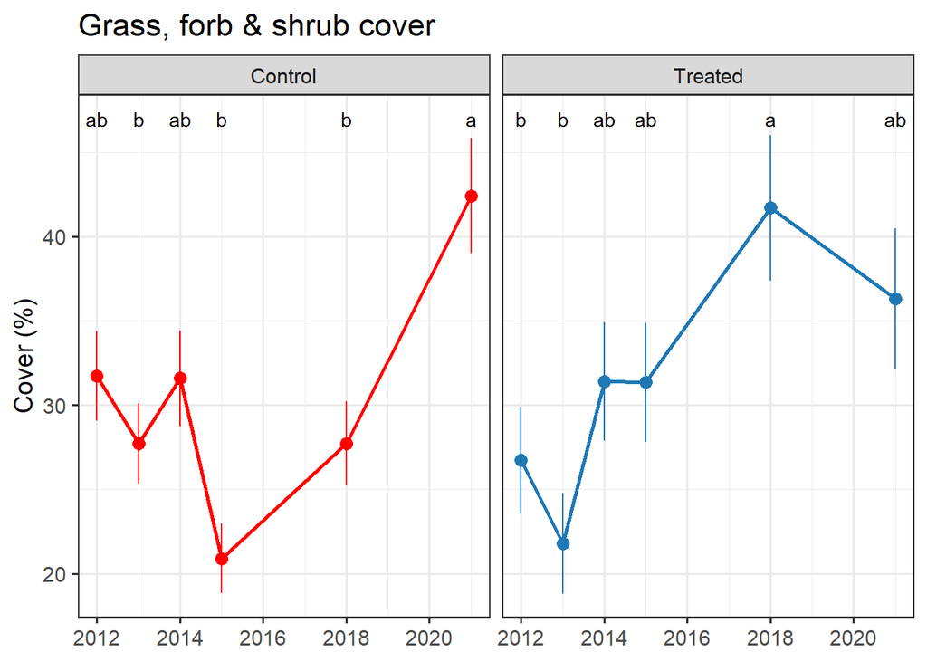

```r
notree.ctrl.letters <- hsd.notree.ctrl$groups
notree.ctrl.letters <- notree.ctrl.letters |>
  mutate(Year = rownames(notree.ctrl.letters)) |>
  arrange(Year)
notree.trt.letters <- hsd.notree.trt$groups
notree.trt.letters <- notree.trt.letters |>
  mutate(Year = rownames(notree.trt.letters)) |>
  arrange(Year)

letters.notree <- data.frame(x = rep(notree.avg$year.xaxis[1:6], 2),
                      y = rep(47, 12),
                      label = c(notree.ctrl.letters$groups,
                                notree.trt.letters$groups),
                      Treatment3 = c(rep("Control", 6),
                                     rep("Treated", 6)))
notree.plot <- ggplot(notree.avg, aes(x = year.xaxis, y = mean,
                       group = Treatment3,
                       color = Treatment3)) +
  geom_line(linewidth = 1) +
  geom_point(size = 3) +
  geom_pointrange(aes(ymin = mean - SE, ymax = mean + SE)) +
  facet_wrap(~Treatment3) +
  xlab(NULL) +
  ylab("Cover (%)") +
  ggtitle("Grass, forb & shrub cover") +
  scale_color_manual(values = c("red", "#1F78B4")) +
  theme_bw(base_size = 14) +
  theme(legend.position = "none") +
  geom_text(data = letters.notree,
            mapping = aes(x = x, y = y, label = label),
            color = "black")
notree.plot
```

# Compare veg cover change

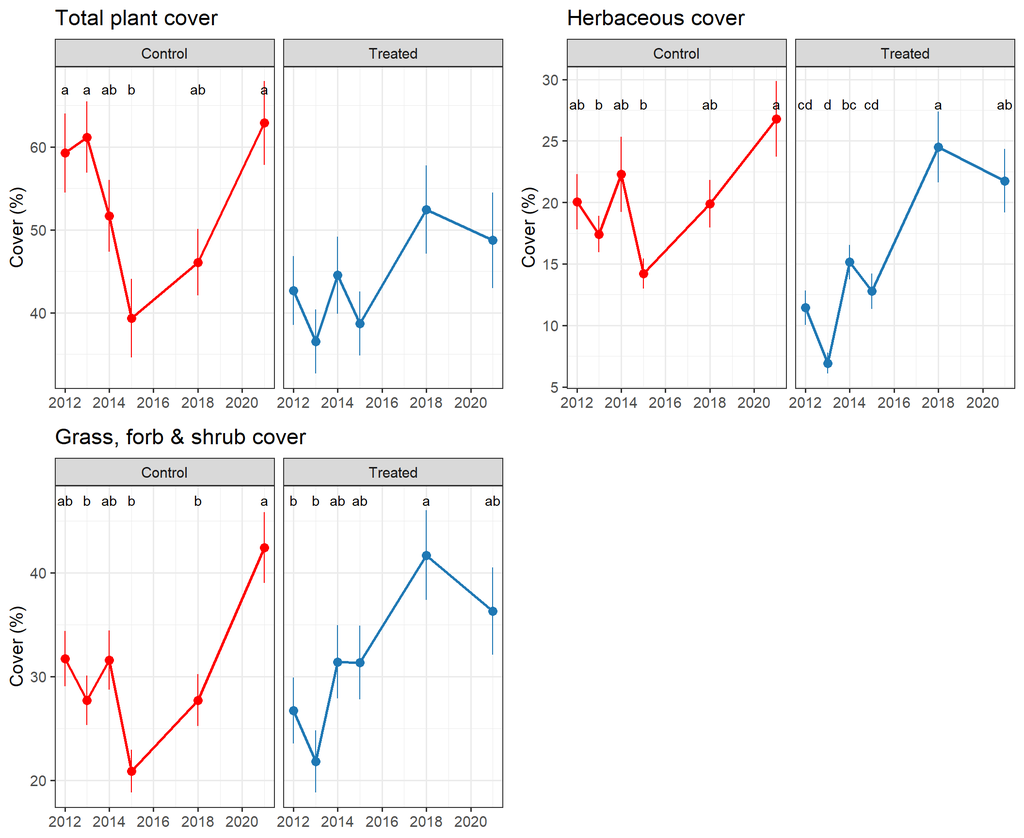

```r
ggarrange(total.plot, herb.plot, notree.plot,
          ncol = 2, nrow = 2)
```

# Perennial richness

## Find averages by year

```r
# Find averages by year
rich.avg <- per.div %>%
  group_by(Treatment3, Year, year.xaxis) %>%
  summarise(mean = mean(rich),
            SD = sd(rich),
            SE = std.error(rich),
            .groups = "keep")

write.csv(rich.avg,
          file = "data/cleaned/Treatment3-average_richness.csv",
          row.names = FALSE)
```

## Plot

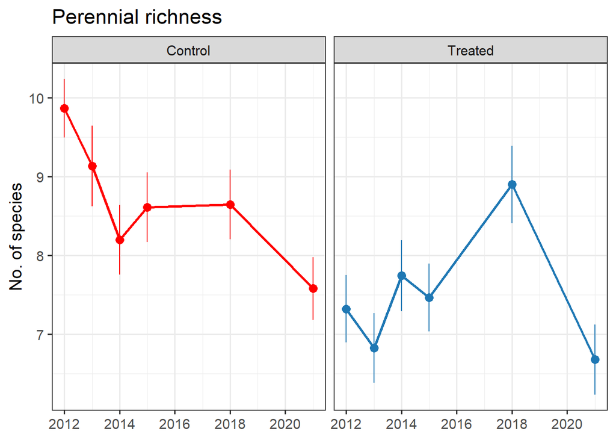

```r
ggplot(rich.avg, aes(x = year.xaxis, y = mean,
                     group = Treatment3,
                     color = Treatment3)) +
  geom_line(linewidth = 1) +
  geom_point(size = 3) +
  geom_pointrange(aes(ymin = mean - SE, ymax = mean + SE)) +
  facet_wrap(~Treatment3) +
  xlab(NULL) +
  ylab("No. of species") +
  ggtitle("Perennial richness") +
  scale_color_manual(values = c("red", "#1F78B4")) +
  theme_bw(base_size = 14) +
  theme(legend.position = "none")
```

## Compare overall Control & Treated

### Repeat measures ANOVA

```r
anova.rich <- aov(rich ~ Treatment3 + Error(Year), data = per.div)
summary(anova.rich)
```

```
##
## Error: Year
##            Df Sum Sq Mean Sq F value Pr(>F)
## Treatment3  1    0.5   0.498    0.02  0.895
## Residuals   4  100.7  25.185
##
## Error: Within
##             Df Sum Sq Mean Sq F value   Pr(>F)
## Treatment3   1  126.3  126.34   20.62 7.65e-06 ***
## Residuals  358 2193.1    6.13
## ---
## Signif. codes:  0 '***' 0.001 '**' 0.01 '*' 0.05 '.' 0.1 ' ' 1
```

```r
summary(aov(rich ~ Treatment3, data = per.div)) # without repeat measures to compare
```

```
##              Df Sum Sq Mean Sq F value   Pr(>F)
## Treatment3    1  126.6  126.55   20.02 1.02e-05 ***
## Residuals   363 2294.1    6.32
## ---
## Signif. codes:  0 '***' 0.001 '**' 0.01 '*' 0.05 '.' 0.1 ' ' 1
```

- Significant difference between channels.

### Year as random factor

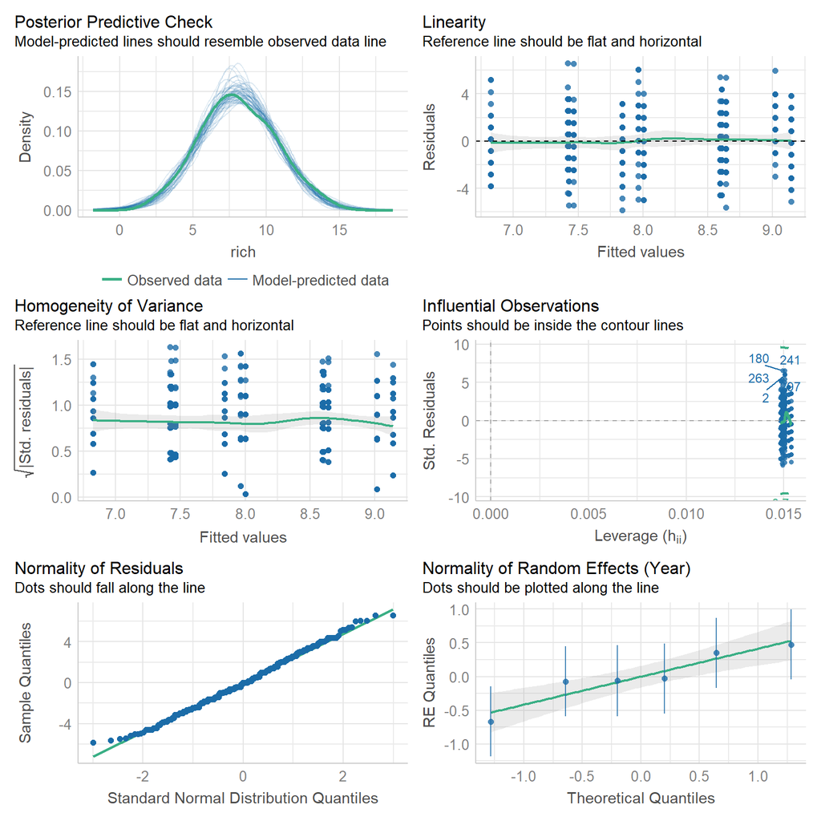

```r
# Using lme4 & car
lm.rich <- lmer(rich ~ Treatment3 + (1|Year), data = per.div)
check_model(lm.rich)
```

```r
Anova(lm.rich)
```

```
## Analysis of Deviance Table (Type II Wald chisquare tests)
##
## Response: rich
##             Chisq Df Pr(>Chisq)
## Treatment3 20.635  1  5.556e-06 ***
## ---
## Signif. codes:  0 '***' 0.001 '**' 0.01 '*' 0.05 '.' 0.1 ' ' 1
```

```r
# Using nlme & emmeans
lm2.rich <- lme(rich ~ Treatment3, random = ~1|Year, data = per.div)
emmeans(lm2.rich, specs = "Treatment3") # Control > Treated
```

```
##  Treatment3 emmean    SE df lower.CL upper.CL
##  Control      8.67 0.268  5     7.98     9.36
##  Treated      7.49 0.268  5     6.80     8.18
##
## Degrees-of-freedom method: containment
## Confidence level used: 0.95
```

- Significant difference between channels.

## Temporal one-way ANOVA

```r
# One-way ANOVA for Treated
summary(aov(rich ~ Year, data = filter(per.div, Treatment3 == "Treated")))
```

```
##              Df Sum Sq Mean Sq F value  Pr(>F)
## Year          5   95.7  19.138   3.137 0.00974 **
## Residuals   176 1073.8   6.101
## ---
## Signif. codes:  0 '***' 0.001 '**' 0.01 '*' 0.05 '.' 0.1 ' ' 1
```

```r
rich.trt <- per.div |>
  filter(Treatment3 == "Treated")
anova.rich.trt <- aov(rich.trt$rich ~ rich.trt$Year)
hsd.rich.trt <- HSD.test(anova.rich.trt, trt = "rich.trt$Year")
hsd.rich.trt
```

```
## $statistics
##    MSerror  Df     Mean       CV
##   6.101071 176 7.489011 32.98212
##
## $parameters
##    test        name.t ntr StudentizedRange alpha
##   Tukey rich.trt$Year   6         4.074882  0.05
##
## $means
##      rich.trt$rich      std  r Min Max Q25 Q50   Q75
## 2012      7.322581 2.385890 31   2  11   6 8.0  9.00
## 2013      6.827586 2.376507 29   2  11   5 7.0  8.00
## 2014      7.741935 2.516184 31   3  14   6 7.0 10.00
## 2015      7.466667 2.359622 30   2  14   6 8.0  8.75
## 2018      8.900000 2.695462 30   3  14   7 9.5 10.00
## 2021      6.677419 2.468294 31   3  12   5 6.0  8.00
##
## $comparison
## NULL
##
## $groups
##      rich.trt$rich groups
## 2018      8.900000      a
## 2014      7.741935     ab
## 2015      7.466667     ab
## 2012      7.322581     ab
## 2013      6.827586      b
## 2021      6.677419      b
##
## attr(,"class")
## [1] "group"
```

```r
# One-way ANOVA for Control
summary(aov(rich ~ Year, data = filter(per.div, Treatment3 == "Control"))) # 0.00881
```

```
##              Df Sum Sq Mean Sq F value  Pr(>F)
## Year          5   92.9  18.587   3.189 0.00881 **
## Residuals   177 1031.7   5.829
## ---
## Signif. codes:  0 '***' 0.001 '**' 0.01 '*' 0.05 '.' 0.1 ' ' 1
```

```r
rich.ctrl <- per.div |>
  filter(Treatment3 == "Control")
anova.rich.ctrl <- aov(rich.ctrl$rich ~ rich.ctrl$Year)
hsd.rich.ctrl <- HSD.test(anova.rich.ctrl, trt = "rich.ctrl$Year")
hsd.rich.ctrl
```

```
## $statistics
##    MSerror  Df     Mean       CV
##   5.829002 177 8.666667 27.85768
##
## $parameters
##    test         name.t ntr StudentizedRange alpha
##   Tukey rich.ctrl$Year   6         4.074627  0.05
##
## $means
##      rich.ctrl$rich      std  r Min Max  Q25 Q50   Q75
## 2012       9.866667 2.046584 30   6  15 8.25 9.5 11.00
## 2013       9.133333 2.800657 30   4  13 7.00 8.0 11.75
## 2014       8.200000 2.426861 30   4  14 7.00 8.5 10.00
## 2015       8.612903 2.458691 31   3  14 7.00 8.0 10.50
## 2018       8.645161 2.470471 31   4  13 6.50 9.0 10.50
## 2021       7.580645 2.217719 31   3  12 6.00 8.0  9.00
##
## $comparison
## NULL
##
## $groups
##      rich.ctrl$rich groups
## 2012       9.866667      a
## 2013       9.133333     ab
## 2018       8.645161     ab
## 2015       8.612903     ab
## 2014       8.200000     ab
## 2021       7.580645      b
##
## attr(,"class")
## [1] "group"
```

## Plot with one-way ANOVA letters

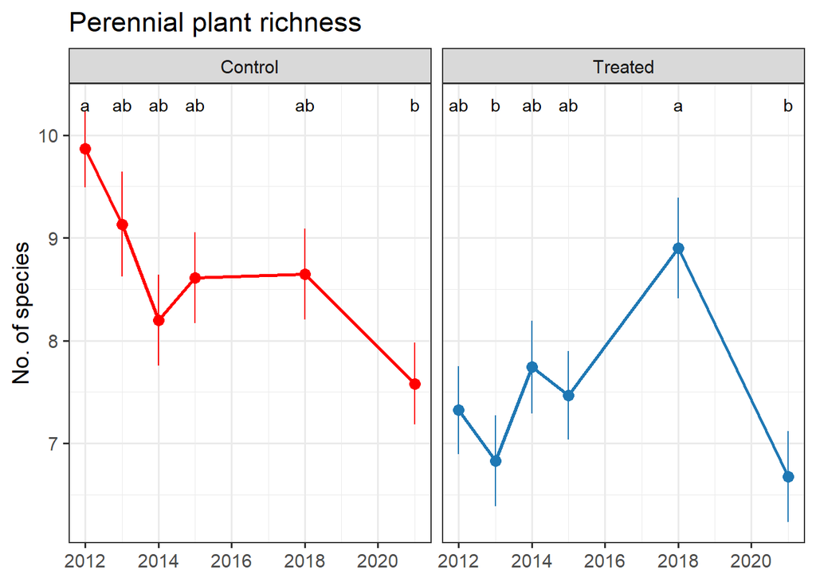

```r
rich.ctrl.letters <- hsd.rich.ctrl$groups
rich.ctrl.letters <- rich.ctrl.letters |>
  mutate(Year = rownames(rich.ctrl.letters)) |>
  arrange(Year)
rich.trt.letters <- hsd.rich.trt$groups
rich.trt.letters <-rich.trt.letters |>
  mutate(Year = rownames(rich.trt.letters)) |>
  arrange(Year)

letters.rich <- data.frame(x = rep(rich.avg$year.xaxis[1:6], 2),
                      y = rep(10.3, 12),
                      label = c(rich.ctrl.letters$groups,
                                rich.trt.letters$groups),
                      Treatment3 = c(rep("Control", 6),
                                     rep("Treated", 6)))
rich.plot <- ggplot(rich.avg, aes(x = year.xaxis, y = mean,
                     group = Treatment3,
                     color = Treatment3)) +
  geom_line(linewidth = 1) +
  geom_point(size = 3) +
  geom_pointrange(aes(ymin = mean - SE, ymax = mean + SE)) +
  facet_wrap(~Treatment3) +
  xlab(NULL) +
  ylab("No. of species") +
  ggtitle("Perennial plant richness") +
  scale_color_manual(values = c("red", "#1F78B4")) +
  theme_bw(base_size = 14) +
  theme(legend.position = "none") +
  geom_text(data = letters.rich,
            mapping = aes(x = x, y = y, label = label),
            color = "black")
rich.plot
```

# Perennial diversity

## Find averages by year

```r
# Find averages by year
shan.avg <- per.div %>%
  group_by(Treatment3, Year, year.xaxis) %>%
  summarise(mean = mean(shan),
            SD = sd(shan),
            SE = std.error(shan),
            .groups = "keep")

write.csv(shan.avg,
          file = "data/cleaned/Treatment3-average_shannon.csv",
          row.names = FALSE)
```

## Plot

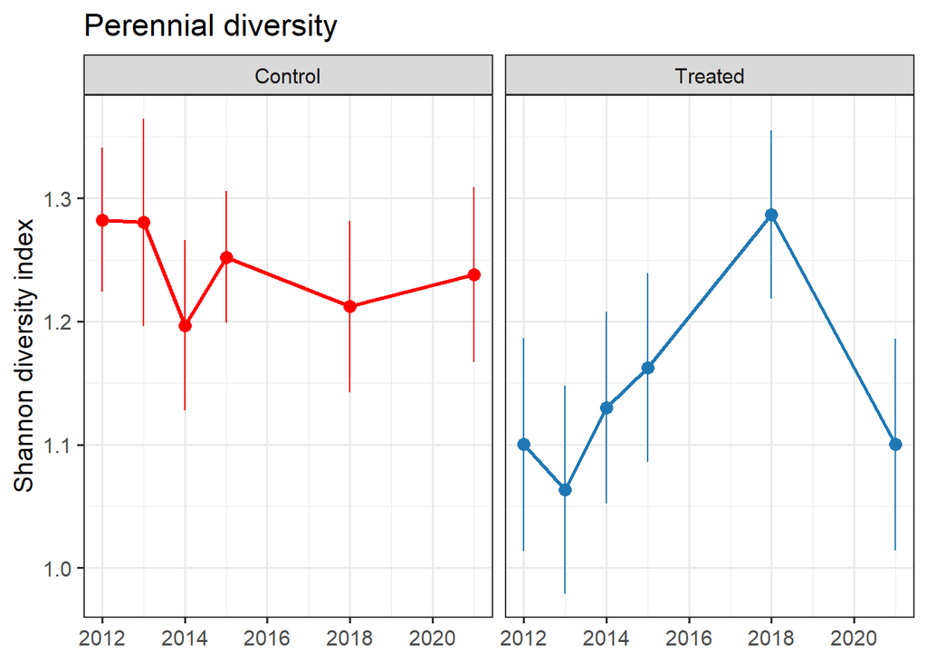

```r
shan.plot <- ggplot(shan.avg, aes(x = year.xaxis, y = mean,
                     group = Treatment3,
                     color = Treatment3)) +
  geom_line(linewidth = 1) +
  geom_point(size = 3) +
  geom_pointrange(aes(ymin = mean - SE, ymax = mean + SE)) +
  facet_wrap(~Treatment3) +
  xlab(NULL) +
  ylab("Shannon diversity index") +
  ggtitle("Perennial diversity") +
  scale_color_manual(values = c("red", "#1F78B4")) +
  theme_bw(base_size = 14) +
  theme(legend.position = "none")
shan.plot
```

## Compare overall Control & Treated

### Repeat measures ANOVA

```r
anova.shan <- aov(shan ~ Treatment3 + Error(Year), data = per.div)
summary(anova.shan)
```

```
##
## Error: Year
##            Df  Sum Sq Mean Sq F value Pr(>F)
## Treatment3  1 0.09265 0.09265   1.653  0.268
## Residuals   4 0.22414 0.05604
##
## Error: Within
##             Df Sum Sq Mean Sq F value Pr(>F)
## Treatment3   1   0.96  0.9597   5.692 0.0176 *
## Residuals  358  60.36  0.1686
## ---
## Signif. codes:  0 '***' 0.001 '**' 0.01 '*' 0.05 '.' 0.1 ' ' 1
```

```r
summary(aov(shan ~ Treatment3, data = per.div)) # without repeat measures to compare
```

```
##              Df Sum Sq Mean Sq F value Pr(>F)
## Treatment3    1   0.97  0.9683   5.794 0.0166 *
## Residuals   363  60.67  0.1671
## ---
## Signif. codes:  0 '***' 0.001 '**' 0.01 '*' 0.05 '.' 0.1 ' ' 1
```

- Significant difference between channels.

### Year as random factor

```r
# Using lme4 & car
lm.shan <- lmer(shan ~ Treatment3 + (1|Year), data = per.div) # something weird is happening here
```

```
## boundary (singular) fit: see help('isSingular')
```

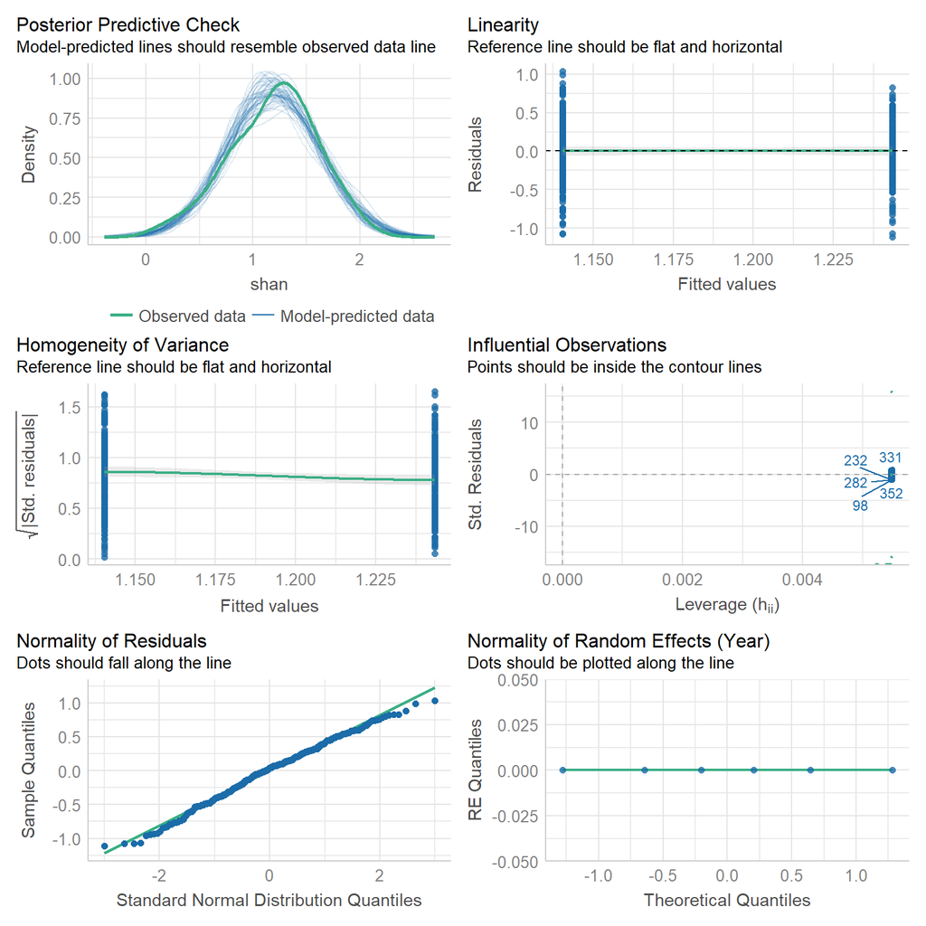

```r
check_model(lm.shan) # something is def not right
```

```r
summary(lm.shan) # why is there no variance? idk
```

```
## Linear mixed model fit by REML ['lmerMod']
## Formula: shan ~ Treatment3 + (1 | Year)
##    Data: per.div
##
## REML criterion at convergence: 391.2
##
## Scaled residuals:
##      Min       1Q   Median       3Q      Max
## -2.72390 -0.65845  0.09456  0.68561  2.52893
##
## Random effects:
##  Groups   Name        Variance Std.Dev.
##  Year     (Intercept) 0.0000   0.0000
##  Residual             0.1671   0.4088
## Number of obs: 365, groups:  Year, 6
##
## Fixed effects:
##                   Estimate Std. Error t value
## (Intercept)        1.24342    0.03022  41.144
## Treatment3Treated -0.10301    0.04280  -2.407
##
## Correlation of Fixed Effects:
##             (Intr)
## Trtmnt3Trtd -0.706
## optimizer (nloptwrap) convergence code: 0 (OK)
## boundary (singular) fit: see help('isSingular')
```

```r
Anova(lm.shan)
```

```
## Analysis of Deviance Table (Type II Wald chisquare tests)
##
## Response: shan
##             Chisq Df Pr(>Chisq)
## Treatment3 5.7937  1    0.01608 *
## ---
## Signif. codes:  0 '***' 0.001 '**' 0.01 '*' 0.05 '.' 0.1 ' ' 1
```

```r
# Using nlme & emmeans
lm2.shan <- lme(shan ~ Treatment3, random = ~1|Year, data = per.div)
emmeans(lm2.shan, specs = "Treatment3")
```

```
##  Treatment3 emmean     SE df lower.CL upper.CL
##  Control      1.24 0.0302  5     1.17     1.32
##  Treated      1.14 0.0303  5     1.06     1.22
##
## Degrees-of-freedom method: containment
## Confidence level used: 0.95
```

- Significant difference between channels.

## Temporal one-way ANOVA

```r
# One-way ANOVA for Treated
summary(aov(shan ~ Year, data = filter(per.div, Treatment3 == "Treated"))) # NS
```

```
##              Df Sum Sq Mean Sq F value Pr(>F)
## Year          5   0.93  0.1863   0.955  0.447
## Residuals   176  34.36  0.1952
```

```r
# One-way ANOVA for Control
summary(aov(shan ~ Year, data = filter(per.div, Treatment3 == "Control"))) # NS
```

```
##              Df Sum Sq Mean Sq F value Pr(>F)
## Year          5  0.185 0.03702    0.26  0.934
## Residuals   177 25.197 0.14235
```